# act_report

## Act report

Twitter Dogs page project.

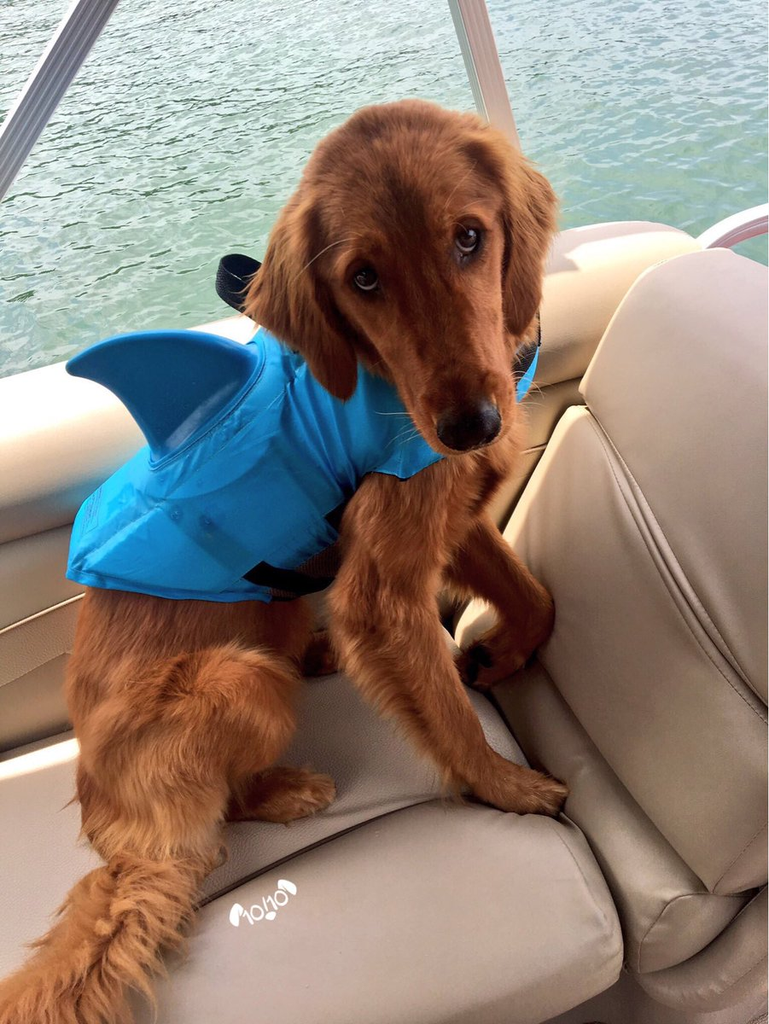

The work is based on the twitter page WeRateDogs. I'have download all the information in three different ways. then i have selected 3 question to analyze:

1.which group of dog is the most common?

2.relation between favorite tweets and retwweted.

3.which is the most used method to share tweets for group of dogs?

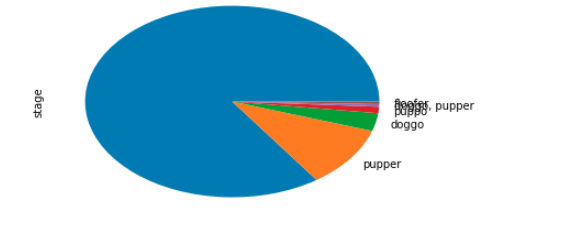

For the second insight we have analyzed the correlation between the retweets and the favourites and is as we can see is a proportional increasing.

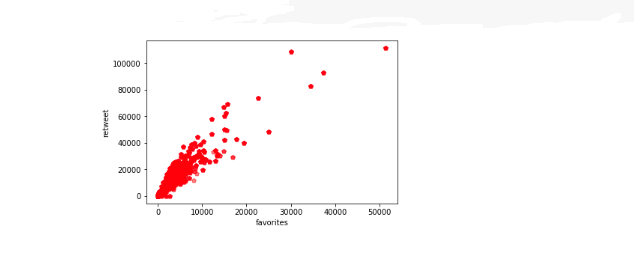

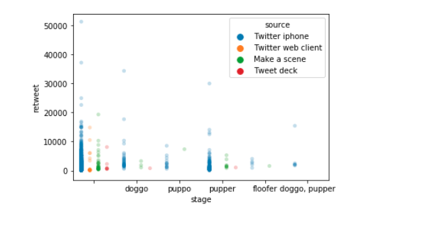

###### conclusion

Conclusion: With these insights we have found different types of conclusion probably not too relevant but with a future revision and more data this could be more precise, and with a continuos update we could find more information as well

limitations: In the current project and database we have a lot of dirty and messy data. I tried to clean as much as i can the database but is still present some wrong or bad information that can lead to distorted results. This could be reflected on the visualizations as well.

[figure not shown]